# Tugas Pertemuan 7

Rifqi Rustu Andana - G1401211067

### Library

```r
library("forecast")
```

```r
library("graphics")
library("TTR")
library("TSA")
library(dplyr)
library(forecast)
library(lmtest)
library(orcutt)
library(HoRM)
library(corrplot)
library(dLagM)
library(dynlm)
library(MLmetrics)
library(ggplot2)
library(tsibble)
library(tseries)
library(MASS)
library(aTSA)
```

# Input data

```r
library(readxl)
datanya <- read_excel("C:/IPB/Semester 5/MPDW/mpdw/Tugas/Tugas1/Suhu Zamboanga.xlsx")
datanya
```

```
## # A tibble: 144 × 2
##    Periode Suhu
##      <dbl> <chr>
##  1       1 27.51
##  2       2 27.85
##  3       3 28.76
##  4       4 29.11
##  5       5 29.63
##  6       6 29.4
##  7       7 28.85
##  8       8 28.72
##  9       9 29.24
## 10      10 29.11
## # ℹ 134 more rows
```

### Ubah data menjadi time series

```r
datanya.ts <- ts(datanya$Suhu)
```

### Membagi data menjadi data latih (80%) dan data uji (20%) dan jadikan time series

```r
dat.latih <- datanya[1:115,2]
dat.uji <- datanya[116:144,2]
dat.latih.ts <- ts(dat.latih, frequency = 12)
dat.uji.ts <- ts(dat.uji, frequency = 12)
```

# Eksplorasi data

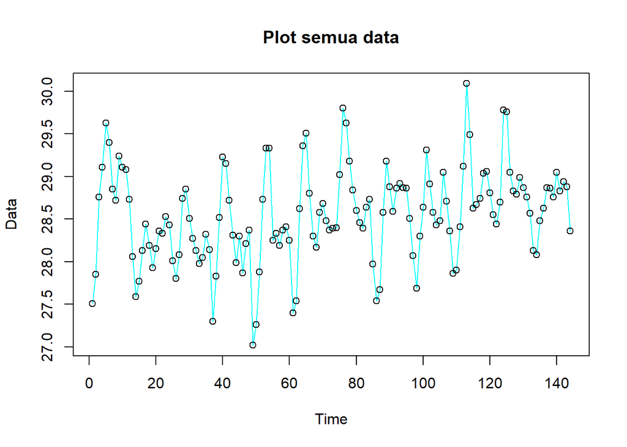

```r
# data full
ts.plot(datanya.ts, col="cyan",main="Plot semua data", type="o",xlab="Time",ylab="Data")
points(datanya.ts)
```

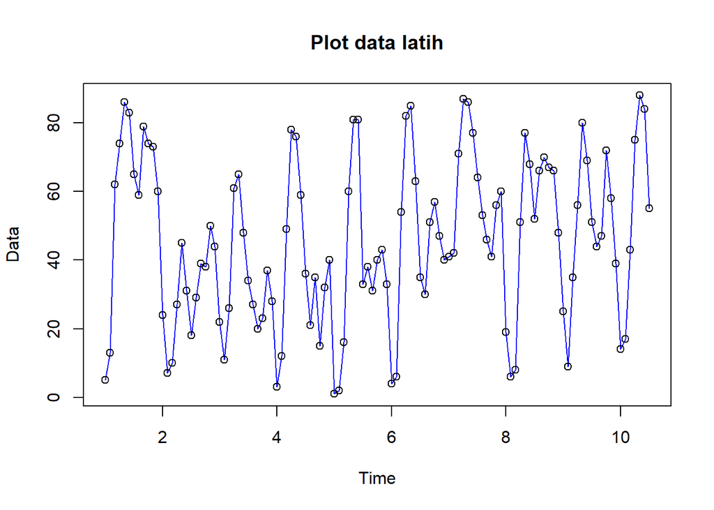

```r
# data latih
ts.plot(dat.latih.ts, col="blue",main="Plot data latih", type="o",xlab="Time",ylab="Data")
points(dat.latih.ts)
```

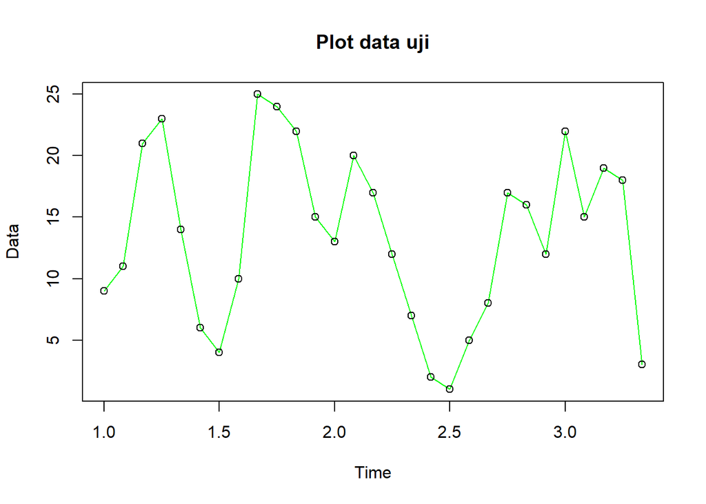

```r
# data uji
ts.plot(dat.uji.ts, col="green",main="Plot data uji", type="o",xlab="Time",ylab="Data")
points(dat.uji.ts)
```

# CEK Stasioner

### Plot acf

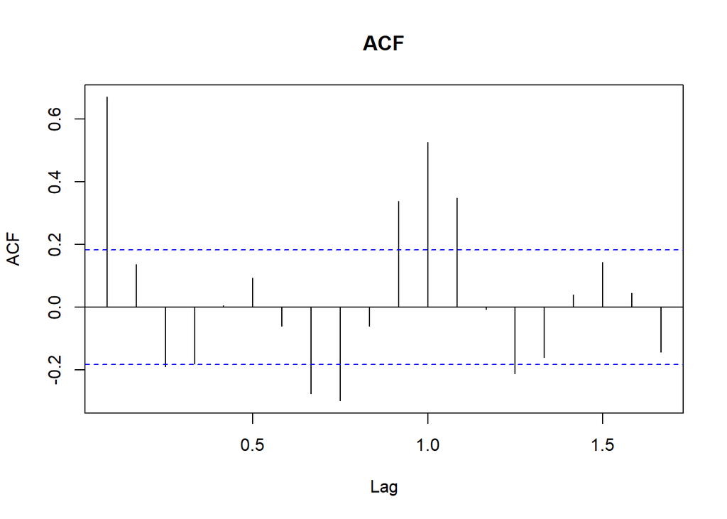

```r
acf(dat.latih.ts, main="ACF", lag.max=20)
```

Berdasarkan plot ACF, terlihat bahwa plot ACF pada data tersebut cenderung *tails off* dan membentuk gelombang sinus. menandakan bahwa data tersebut stasioner dalam rataan

### Uji ADF

```r
tseries::adf.test(dat.latih.ts)
```

```
##
##  Augmented Dickey-Fuller Test
##
## data:  dat.latih.ts
## Dickey-Fuller = -4.0353, Lag order = 4, p-value = 0.01
## alternative hypothesis: stationary
```

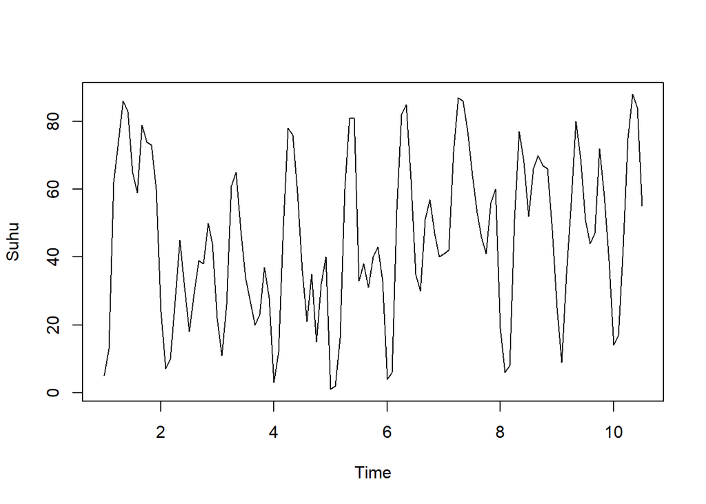

```r
train.diff<-diff(dat.latih.ts,differences = 2)
plot.ts(dat.latih.ts, lty=1)
```

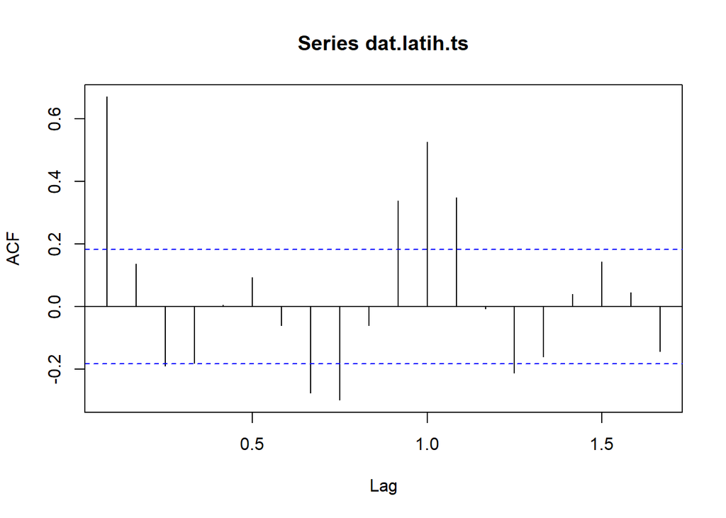

```r
acf(dat.latih.ts)
```

$H_0$ : Data tidak stasioner dalam rataan, & $H_1$ : Data stasioner dalam rataan

Berdasarkan uji ADF, didapat *p-value* sebesar 0.01 yang lebih kecil dari alpha 5% sehingga tolak $H_0$, artinya data stasioner dalam rataan. Hal ini sesuai dengan hasil eksplorasi menggunakan plot time series dan plot ACF.

### Plot Box-Cox

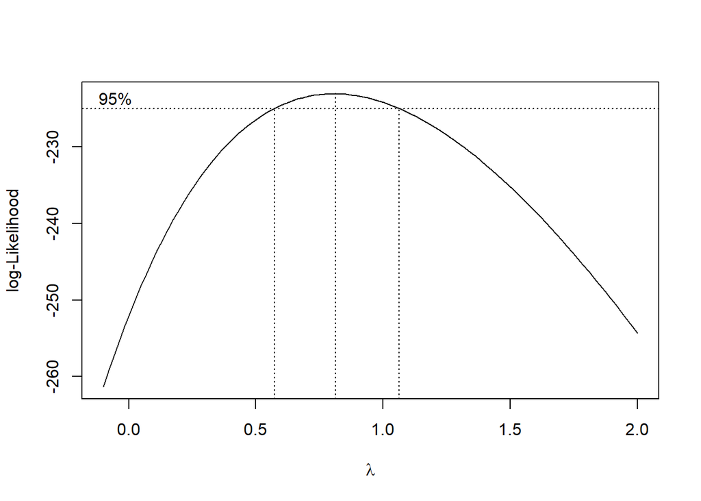

```r
index <- seq(1:115)
bc = boxcox(dat.latih.ts~index, lambda = seq(-0.1,2.,by=0.1))
```

```r
#Nilai Rounded Lambda
lambda <- bc$x[which.max(bc$y)]
lambda
```

```
## [1] 0.8121212
```

```r
#SK
bc$x[bc$y > max(bc$y) - 1/2 * qchisq(.95,1)]
```

```
##  [1] 0.5787879 0.6000000 0.6212121 0.6424242 0.6636364 0.6848485 0.7060606
##  [8] 0.7272727 0.7484848 0.7696970 0.7909091 0.8121212 0.8333333 0.8545455
## [15] 0.8757576 0.8969697 0.9181818 0.9393939 0.9606061 0.9818182 1.0030303
## [22] 1.0242424 1.0454545
```

# Identifikasi model

### Plot ACF dan PACF

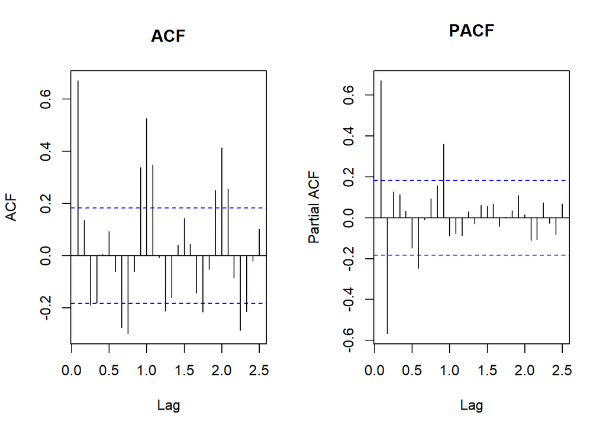

```r
par(mfrow = c(1,2))
acf(dat.latih.ts, main="ACF", lag.max=30) #ARIMA(0,0,2)
pacf(dat.latih.ts, main="PACF", lag.max=30) #ARIMA(1,0,0)
```

### Plot EACF

```r
eacf(dat.latih.ts)
```

```
## AR/MA
##   0 1 2 3 4 5 6 7 8 9 10 11 12 13
## 0 x o o o o o o x x o x  x  x  o
## 1 x x x o o o o x x o x  x  x  o
## 2 o x o o o o o o o o x  o  x  o
## 3 x x o o o o o o o o x  o  o  o
## 4 o x o o o o o o o o o  o  o  o
## 5 o x x o o o o o o o o  x  o  o
## 6 x x x o o o o o o o o  x  o  x
## 7 o x x x o o o o o o o  o  o  o
```

sehingga model tentafifnya ialah ARIMA(0,0,1) ARIMA(2,0,0), ARIMA(2,0,2)

# Pendugaan Parameter

### ARIMA (0,0,1)

```r
model1=Arima(dat.latih.ts, order=c(0,0,1),method="ML")
summary(model1) #AIC=980.28
```

```
## Series: dat.latih.ts
## ARIMA(0,0,1) with non-zero mean
##
## Coefficients:
##          ma1     mean
##       0.7728  45.5274
## s.e.  0.0531   2.7440
##
## sigma^2 = 282.5:  log likelihood = -487.14
## AIC=980.28   AICc=980.49   BIC=988.51
##
## Training set error measures:
##                      ME     RMSE      MAE       MPE     MAPE      MASE
## Training set 0.05116665 16.66148 13.68768 -82.61191 103.4702 0.8357033
##                   ACF1
## Training set 0.2939053
```

```r
lmtest::coeftest(model1) #signifikan
```

```
##
## z test of coefficients:
##
##           Estimate Std. Error z value  Pr(>|z|)
## ma1        0.77279    0.05309  14.556 < 2.2e-16 ***
## intercept 45.52743    2.74398  16.592 < 2.2e-16 ***
## ---
## Signif. codes:  0 '***' 0.001 '**' 0.01 '*' 0.05 '.' 0.1 ' ' 1
```

### ARIMA (2,0,0)

```r
model2=Arima(dat.latih.ts, order=c(2,0,0),method="ML")
summary(model2) #AIC=946.31
```

```
## Series: dat.latih.ts
## ARIMA(2,0,0) with non-zero mean
##
## Coefficients:
##          ar1      ar2     mean
##       1.0792  -0.5930  45.3274
## s.e.  0.0755   0.0763   2.5852
##
## sigma^2 = 207.5:  log likelihood = -469.16
## AIC=946.31   AICc=946.68   BIC=957.29
##
## Training set error measures:
##                      ME     RMSE      MAE      MPE     MAPE      MASE
## Training set 0.01445205 14.21425 10.89734 -68.8383 89.36117 0.6653383
##                    ACF1
## Training set 0.05640998
```

```r
lmtest::coeftest(model2) #signifikan
```

```
##
## z test of coefficients:
##
##            Estimate Std. Error z value  Pr(>|z|)
## ar1        1.079154   0.075493 14.2947 < 2.2e-16 ***
## ar2       -0.592970   0.076329 -7.7686 7.934e-15 ***
## intercept 45.327447   2.585236 17.5332 < 2.2e-16 ***
## ---
## Signif. codes:  0 '***' 0.001 '**' 0.01 '*' 0.05 '.' 0.1 ' ' 1
```

### ARIMA (2,0,2)

```r
model3=Arima(dat.latih.ts, order=c(2,0,2),method="ML")
summary(model3) #AIC=947.1
```

```
## Series: dat.latih.ts
## ARIMA(2,0,2) with non-zero mean
##
## Coefficients:
##          ar1      ar2     ma1     ma2     mean
##       0.8774  -0.5405  0.2276  0.2208  45.3759
## s.e.  0.1461   0.1160  0.1586  0.1332   2.8511
##
## sigma^2 = 205.2:  log likelihood = -467.55
## AIC=947.1   AICc=947.87   BIC=963.57
##
## Training set error measures:
##                      ME     RMSE      MAE       MPE     MAPE      MASE
## Training set 0.02617679 14.01089 10.64787 -67.60173 90.96815 0.6501068
##                   ACF1
## Training set 0.0122424
```

```r
lmtest::coeftest(model3) #Tidak Signifikan
```

```
##
## z test of coefficients:
##
##           Estimate Std. Error z value  Pr(>|z|)
## ar1        0.87744    0.14609  6.0062 1.899e-09 ***
## ar2       -0.54050    0.11602 -4.6587 3.183e-06 ***
## ma1        0.22760    0.15861  1.4349   0.15131
## ma2        0.22075    0.13318  1.6576   0.09741 .
## intercept 45.37588    2.85105 15.9155 < 2.2e-16 ***
## ---
## Signif. codes:  0 '***' 0.001 '**' 0.01 '*' 0.05 '.' 0.1 ' ' 1
```

# analisis sisaan

### Eksplorasi

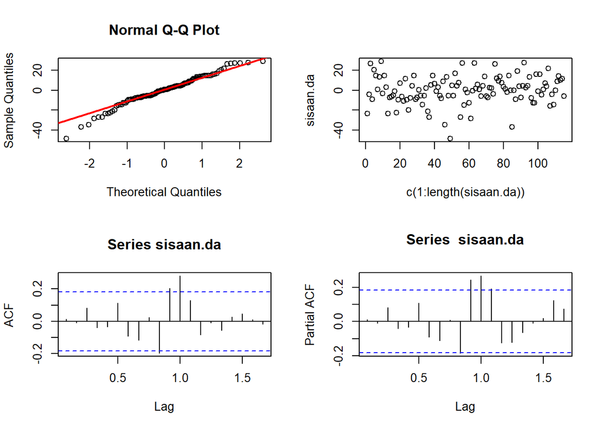

```r
#Eksplorasi
sisaan.da <- model3$residuals
par(mfrow=c(2,2))
qqnorm(sisaan.da)
qqline(sisaan.da, col = "red", lwd = 2)
plot(c(1:length(sisaan.da)),sisaan.da)
acf(sisaan.da)
pacf(sisaan.da)
```

```r
par(mfrow = c(1,1))
```

### Uji Formal

```r
#1) Sisaan Menyebar Normal
ks.test(sisaan.da,"pnorm")
```

```
##
##  Asymptotic one-sample Kolmogorov-Smirnov test
##
## data:  sisaan.da
## D = 0.43214, p-value < 2.2e-16
## alternative hypothesis: two-sided
```

$H_0$ : Sisaan menyebar normal

$H_1$ : Sisaan tidak menyebar normal

Berdasarkan uji KS tersebut, didapat *p-value* sebesar 2.2e-16 yang kurang dari taraf nyata 5% sehingga tolak $H_0$ dan menandakan bahwa sisaan tidak menyebar normal. Hal ini sesuai dengan hasil eksplorasi menggunakan plot kuantil-kuantil normal.

```r
#2) Sisaan saling bebas/tidak ada autokorelasi
Box.test(sisaan.da, type = "Ljung")
```

```
##
##  Box-Ljung test
##
## data:  sisaan.da
## X-squared = 0.017689, df = 1, p-value = 0.8942
```

$H_0$ : Sisaan saling bebas

$H_1$ : Sisaan tidak tidak saling bebas

Berdasarkan uji Ljung-Box tersebut, didapat *p-value* sebesar 0.8942 yang lebih besar dari taraf nyata 5% sehingga tak tolak $H_0$ dan menandakan bahwa sisaan saling bebas. Artinya tidak ada autokorelasi

```r
#3) Sisaan homogen
Box.test((sisaan.da)^2, type = "Ljung")
```

```
##
##  Box-Ljung test
##
## data:  (sisaan.da)^2
## X-squared = 1.7179, df = 1, p-value = 0.19
```

$H_0$ : Ragam sisaan homogen

$H_1$ : Ragam sisaan tidak homogen

Berdasarkan uji Ljung-Box tersebut. didapat *p-value* sebesar 0.19 yang lebih besar dari taraf nyata 5% sehingga tak tolak $H_0$ dan menandakan bahwa ragam sisaan homogen

```r
#4) Nilai tengah sisaan sama dengan nol
t.test(sisaan.da, mu = 0, conf.level = 0.95)  #tak tolak h0 > nilai tengah sisaan sama dengan 0
```

```
##
##  One Sample t-test
##
## data:  sisaan.da
## t = 0.019948, df = 114, p-value = 0.9841
## alternative hypothesis: true mean is not equal to 0
## 95 percent confidence interval:
##  -2.573357  2.625710
## sample estimates:
##  mean of x
## 0.02617679
```

$H_0$ : nilai tengah sisaan sama dengan 0

$H_1$ : nilai tengah sisaan tidak sama dengan 0

Berdasarkan uji-ttersebut, didapat *p-value* sebesar 0.9841 yang lebih besar dari taraf nyata 5% sehingga tak tolak $H_0$ dan menandakan bahwa nilai tengah sisaan sama dengan 0